# Text Mining Final Project

2d Lt Maxwell Thompson

12/4/2019

## R Markdown

This is an R Markdown document

```r
cat("\014") #Clear console
```

```r
rm(list = ls()) #clear variables
library(pacman)
```

```r
pacman::p_load( broom,
                coreNLP,
                dplyr,
                DT,
                ggplot2,
                ggraph,
                grid,
                here,
                igraph,
                knitr,
                lattice,
                LSAfun,
                magrittr,
                monkeylearn,
                NLP,
                openNLP,
                pdftools,
                qdap,
                qdapDictionaries,
                qdapRegex,
                qdapTools,
                quanteda,
                RColorBrewer,
                reshape2,
                rJava,
                RWeka,
                scales,
                SnowballC,
                spacyr,
                stringr,
                tau,
                text2vec,
                textdata,
                textmineR,
                textrank,
                tidyr,
                tidytext,
                tidytext,
                tidyverse,
                tm,
                tokenizers,
                udpipe,
                widyr,
                wordcloud,
                XML
)
```

## Loading and Cleaning the Data

To begin I downloaded the script of the movie Elf from the website listed below.Then i rank it through a series of functions and substitutions. These subsitutions were nessisary to enhance my Named Entity Recognition.

```r
#URL
url  <- 'https://www.springfieldspringfield.co.uk/movie_script.php?movie=elf'
#Grabs data from URL
rcurl.doc <- RCurl::getURL(url,.opts = RCurl::curlOptions(followlocation = TRUE))
#Converts data from html to text
url_parsed <- XML::htmlParse(rcurl.doc, asText = TRUE)

#Create Text1
  text1 =  XML::xpathSApply(url_parsed, "//div[@class='scrolling-script-container']", xmlValue)
  rm(url,rcurl.doc,url_parsed)

#Perfrom substitutions to fix errors and enhance NER
  text1 = gsub('\\\n', "", text1)
  text1 = gsub('\\  ', "", text1)
  text1 = gsub("Mmm","Mm", text1)
  text1 = gsub("Susan wells","Susan", text1)
  text1 = gsub("Walter Hobbs","Walter", text1)
  text1 = gsub("papa","Papa", text1)
  text1 = gsub("Papa Elf","Papa", text1)
  text1 = gsub("new York City","New York", text1)
  text1 = gsub("mike","Michael", text1)
  text1 = gsub("Ho ho ho ho ho","Ho ho ho", text1)
  text1 = gsub("ho ho ho","Ho ho ho", text1)
  text1 = gsub("greenway","Greenway", text1)
  text1 = gsub("charlotte","Charlotte", text1)
  text1 = gsub("chuck","Chuck", text1)
  text1 = gsub("Claus meter","Clause Meter", text1)
  text1 = gsub("elf","Elf", text1)
  text1 = gsub("Never","never", text1)
  text1 = gsub("a, san","a, Santa", text1)
  text1 = gsub("Lincoln tunnel","Lincoln Tunnel", text1)
  text1 = gsub("Aspires","aspires", text1)
  text1 = gsub("Wandering","wandering", text1)
  text1 = gsub("Spread","spread", text1)
  text1 = gsub("Behind","behind", text1)
  text1 = gsub("Carolyn Reynolds","Carolyn", text1)
  text1 = gsub("Decisin","decision", text1)
  text1 = gsub("D,","",text1)
  text1 = gsub("D...","",text1)

  text1 <- gsub("Santa clausis","Santa Claus",text1)
  text1 <- gsub("Santa Clausis","Santa Claus",text1)
  text1 <- gsub("Santa claus","Santa",text1)
  text1 <- gsub("Santa Claus","Santa",text1)
  text1 <- gsub("ray's pizzas","Rays Pizzas",text1)
  text1 <- gsub("Nice list","Nice_List",text1)
  text1 <- gsub("ho!","ho",text1)
  text1 <- gsub("Run","run",text1)
```

## Named Entity Recognition

I begin by putting my data into a dataframe.

```r
text2=data.frame(text1,stringsAsFactors = FALSE)
names(text2)<-"col1"
str(text2)
```

```
## 'data.frame':    1 obs. of  1 variable:
##  $ col1: chr "Oh, hello. You're, uh, you're probably here About the, Uh, the story. Elves love to tell stories. I- I'll bet y"| __truncated__
```

Next, I used ‘Spacy’ to do NER. The first time you use SpacyR you must install it. Then, you must initialize it.

```r
#spacy_install() #only used once
spacy_initialize(model="en_core_web_sm")
```

```
## Found 'spacy_condaenv'. spacyr will use this environment
```

```
## successfully initialized (spaCy Version: 2.2.3, language model: en_core_web_sm)
```

```
## (python options: type = "condaenv", value = "spacy_condaenv")
```

Next, NER is ran and the outputs are saved and reported.

```r
presentation_parsed <- spacy_parse(text2$col1, entity = TRUE)
head(presentation_parsed)
```

```
##   doc_id sentence_id token_id token  lemma   pos entity
## 1  text1           1        1    Oh     oh  INTJ
## 2  text1           1        2     ,      , PUNCT
## 3  text1           1        3 hello  hello  INTJ
## 4  text1           1        4     .      . PUNCT
## 5  text1           2        1   You -PRON-  PRON
## 6  text1           2        2   're     be   AUX
```

```r
full_extracted <- entity_extract(presentation_parsed)
head(full_extracted)
```

```
##   doc_id sentence_id          entity entity_type
## 1  text1          11             Elf        WORK
## 2  text1          24           Santa         GPE
## 3  text1          28             Elf         ORG
## 4  text1          32           Santa         GPE
## 5  text1          49 Merry_Christmas      PERSON
## 6  text1          50              Mm      PERSON
```

Next, manual correction were made for what Spacy got wrong.

```r
for (i in 1:nrow(full_extracted)) {
  if (full_extracted$entity[i]== "Santa" ||
      full_extracted$entity[i]== "Leon"  ||
      full_extracted$entity[i]== "Baby"  ||
      full_extracted$entity[i]== "Charlotte"  ||
      full_extracted$entity[i]== "arctic_puffin"  ||
      full_extracted$entity[i]=="Francisco" ||
      full_extracted$entity[i]=="Elf") {
    full_extracted$entity_type[i]="PERSON"
  }
  if (full_extracted$entity[i]== "Mm" ||
      full_extracted$entity[i]== "Ho_ho_ho" ||
      full_extracted$entity[i]== "Yaah" ||
      full_extracted$entity[i]== "syrup" ||
      full_extracted$entity[i]== "yoursElf" ||
      full_extracted$entity[i]== "Merry_Christmas" ){
    full_extracted$entity_type[i]="Other"
  }
  if (full_extracted$entity[i]== "the_candy_cane_forest" ||
      full_extracted$entity[i]== "the_Lincoln_Tunnel"){
    full_extracted$entity_type[i]="LOC"
  }
  if (full_extracted$entity[i]== "Paparazzi"){
    full_extracted$entity_type[i]="ORG"
  }
}
```

Witht this correct information, I generated a chart of the number of each type of entity.

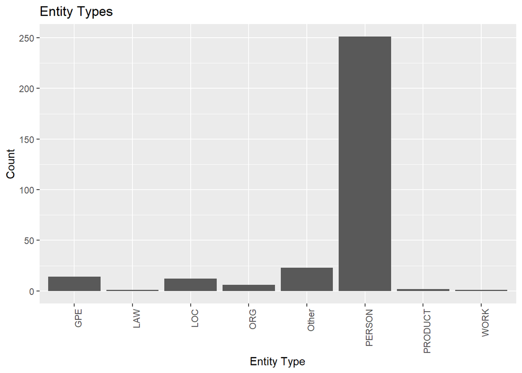

```r
#Entity Types
full_extracted %>%
  count(entity_type) %>%
  top_n(100) %>%
  ggplot(aes(x = entity_type, y = n)) +
  geom_bar(stat = "identity") +
  theme(axis.text.x = element_text(angle = 90, hjust = 1)) +
  labs(title = "Entity Types") +
  xlab("Entity Type") +
  ylab("Count")
```

Then charts of the “organizations,” people, locations, and all other entities.

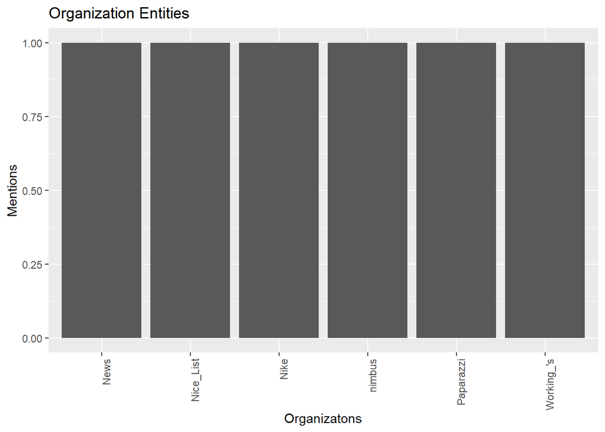

```r
#Organization
full_extracted %>%
  filter(entity_type == "ORG") %>%
  group_by(entity_type) %>%
  count(entity) %>%
  top_n(300) %>%
  ggplot(aes(x = entity, y = n)) +
  geom_bar(stat = "identity") +
  theme(axis.text.x = element_text(angle = 90, hjust = 1)) +
  labs(title = "Organization Entities") +
  xlab("Organizatons") +
  ylab("Mentions")
```

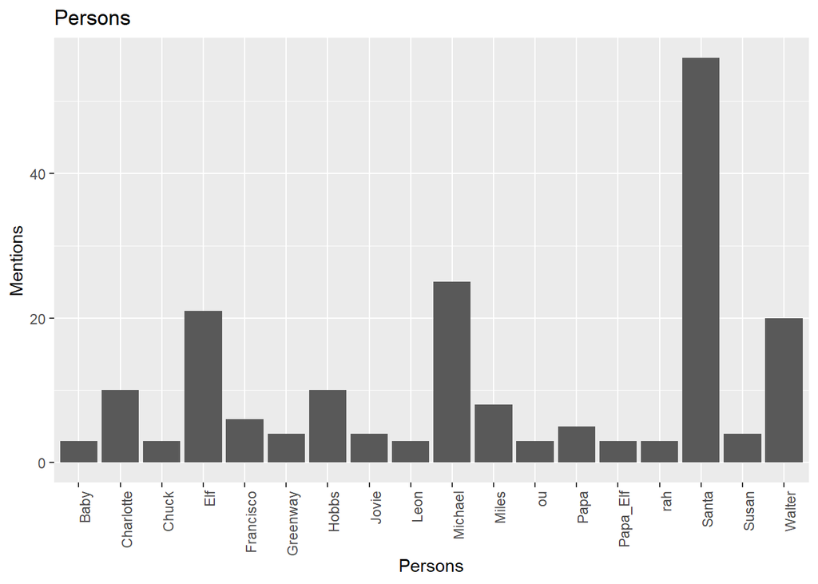

```r
#Persons
full_extracted %>%
  filter(entity_type == "PERSON" ) %>%
  group_by(entity_type) %>%
  count(entity) %>%
  top_n(15) %>%
  ggplot(aes(x = entity, y = n)) +
  geom_bar(stat = "identity") +
  theme(axis.text.x = element_text(angle = 90, hjust = 1)) +
  labs(title = "Persons") +
  xlab("Persons") +
  ylab("Mentions")
```

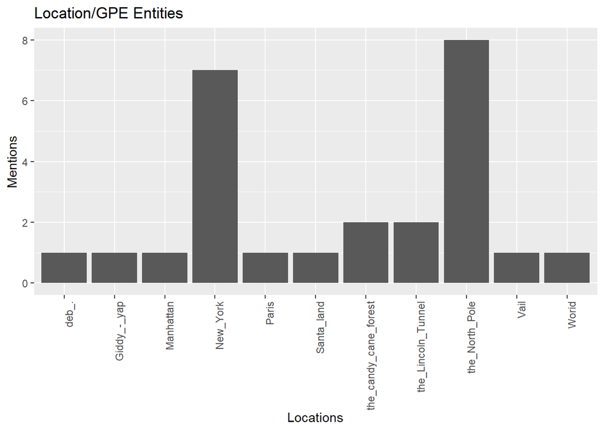

```r
#Location
full_extracted %>%
  filter(entity_type == "LOC" | entity_type == "GPE") %>%
  group_by(entity_type) %>%
  count(entity) %>%
  top_n(100) %>%
  ggplot(aes(x = entity, y = n)) +
  geom_bar(stat = "identity") +
  theme(axis.text.x = element_text(angle = 90, hjust = 1)) +
  labs(title = "Location/GPE Entities") +
  xlab("Locations") +
  ylab("Mentions")
```

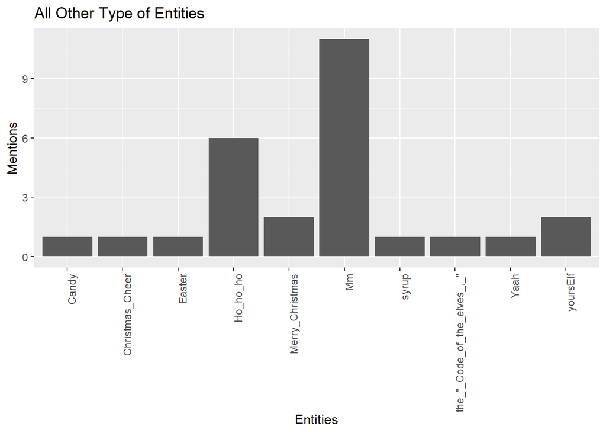

```r
#All Other Type of Entities
full_extracted %>%
  filter(entity_type != "PERSON" & entity_type != "LOC" & entity_type != "GPE" & entity_type != "ORG" ) %>%
  group_by(entity_type) %>%
  count(entity) %>%
  top_n(100) %>%
  ggplot(aes(x = entity, y = n)) +
  geom_bar(stat = "identity") +
  theme(axis.text.x = element_text(angle = 90, hjust = 1))+
  labs(title = "All Other Type of Entities") +
  xlab("Entities") +
  ylab("Mentions")
```

I also used the NER data to identity parts of speech and charted them.

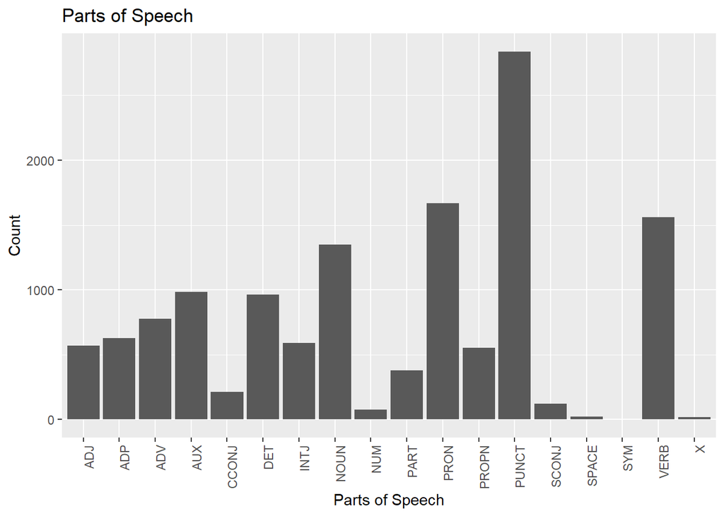

```r
#Parts of Speech
presentation_parsed %>%
  group_by(pos) %>%
  count(entity) %>%
  ggplot(aes(x = pos, y = n)) +
  geom_bar(stat = "identity") +
  theme(axis.text.x = element_text(angle = 90, hjust = 1))+
  labs(title = "Parts of Speech") +
  xlab("Parts of Speech") +
  ylab("Count")
```

```r
rm(i)
```

## Sentiment Analysis

First, the data is prepared into a vector of words.

```r
raw_tb <- tibble::tibble(text = text1)
word_vect = raw_tb %>% tidytext::unnest_tokens(word, text, token = 'words')
text=as_tibble(word_vect)
rm(raw_tb,word_vect)
head(text)
```

```
## # A tibble: 6 x 1
##   word
##   <chr>
## 1 oh
## 2 hello
## 3 you're
## 4 uh
## 5 you're
## 6 probably
```

Next, words that represent sentiments for ‘joy’ and ‘anger’ are loading into R. Then, the words that are in the script are compared to these and displayed.

```r
nrc_joy <- get_sentiments("nrc") %>%
  filter(sentiment == "joy")
nrc_anger <- get_sentiments("nrc") %>%
  filter(sentiment == "anger")

text %>%
  inner_join(nrc_joy) %>%
  count(word, sort = T)
```

```
## # A tibble: 75 x 2
##    word        n
##    <chr>   <int>
##  1 buddy      83
##  2 good       36
##  3 love       21
##  4 baby       11
##  5 sing       11
##  6 fun         8
##  7 special     8
##  8 tickle      8
##  9 tree        8
## 10 food        7
## # ... with 65 more rows
```

```r
text %>%
  inner_join(nrc_anger) %>%
  count(word, sort = T)
```

```
## # A tibble: 46 x 2
##    word        n
##    <chr>   <int>
##  1 elf        36
##  2 bad        10
##  3 tree        8
##  4 fight       7
##  5 evil        4
##  6 cane        3
##  7 broken      2
##  8 crazy       2
##  9 hurt        2
## 10 hurting     2
## # ... with 36 more rows
```

Word cloud of positive verse negative words

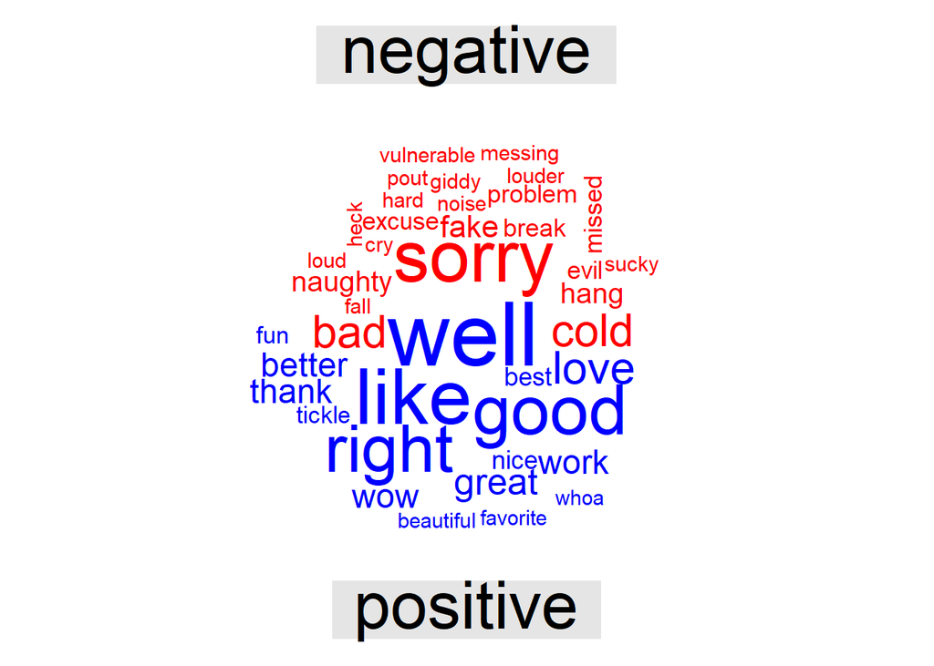

```r
text %>%
  inner_join(get_sentiments("bing")) %>%
  count(word, sentiment, sort = TRUE) %>%
  acast(word ~ sentiment, value.var = "n", fill = 0) %>%
  comparison.cloud(colors = c("red","blue"),
                   max.words = 40)
```

Word cloud of words in in script that are not ‘stop words.’

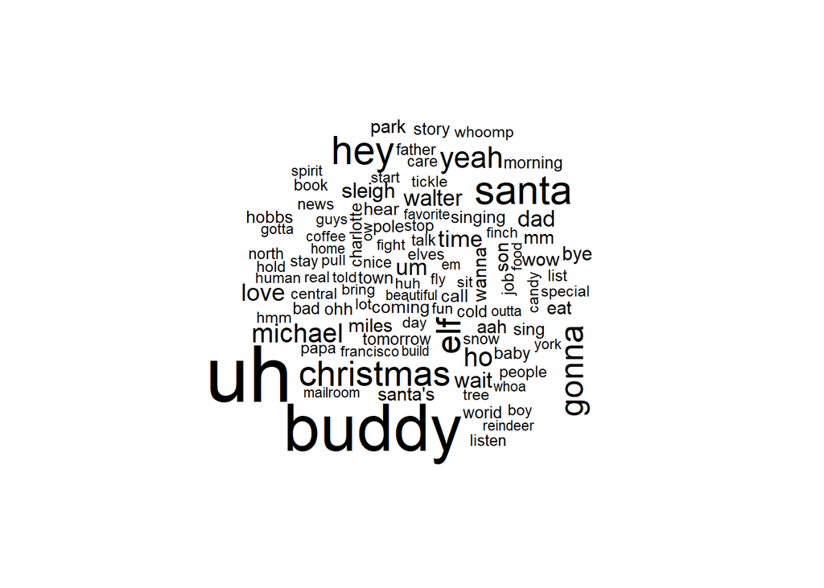

```r
text %>%
  anti_join(stop_words) %>%
  count(word) %>%
  with(wordcloud(word, n, max.words = 100))
```

Same positive/negative chart but without stop words.

```r
text = text %>%
  dplyr::anti_join(stop_words)
```

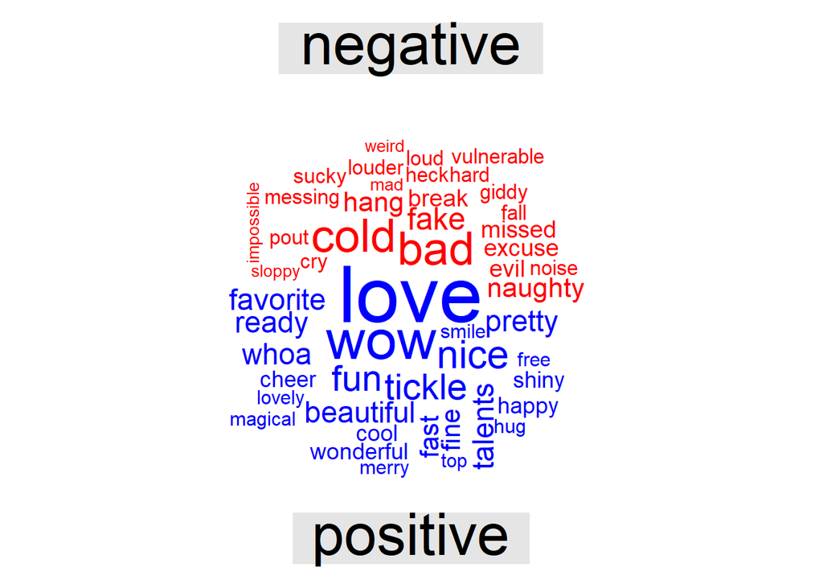

```r
text %>%
  inner_join(get_sentiments("bing")) %>%
  count(word, sentiment, sort = TRUE) %>%
  acast(word ~ sentiment, value.var = "n", fill = 0) %>%
  comparison.cloud(colors = c("red","blue"),
                   max.words = 50)
```

## Document Summary

Format data

```r
text3=data.frame(text1,stringsAsFactors = FALSE)
names(text3)<-"col1"
str(text3)
```

```
## 'data.frame':    1 obs. of  1 variable:
##  $ col1: chr "Oh, hello. You're, uh, you're probably here About the, Uh, the story. Elves love to tell stories. I- I'll bet y"| __truncated__
```

```r
sentences_1 <- unnest_tokens(tbl=text3,input=col1,output=sentences_1,token = "sentences")
text=sentences_1[,1]
```

## Including Plots

```r
article_sentences <- tibble(text = text) %>%
  unnest_tokens(sentence, text, token = "sentences") %>%
  mutate(sentence_id = row_number()) %>%
  select(sentence_id, sentence)

article_words <- article_sentences %>%
  unnest_tokens(word, sentence)

article_words <- article_words %>%
  anti_join(stop_words, by = "word")

# article_summary <- textrank_sentences(data = article_sentences,
#                                       terminology = article_words)
#                   #this part takes awhile
# saveRDS(article_summary,"C:/Users/Max's USAFA PC/Documents/SCHOOL/article_summary.RDS")

article_summary = readRDS("C:/Users/Max's USAFA PC/Documents/SCHOOL/article_summary.RDS")

#This shows us the top three sentences that summarize the document
a_s_2<- article_summary[["sentences"]] %>%
  arrange(desc(textrank)) %>%
  slice(1:10) %>%
  pull(sentence)
```

[output not shown]

```r
character_count(text1)
```

```
## [1] 38182
```

```r
# g_sum_d = genericSummary(text1,20,min = 2)
# g_sum_d = unique(g_sum_d)
# saveRDS(g_sum_d,"C:/Users/Max's USAFA PC/Documents/SCHOOL/g_sum_d.RDS")

# g_sum_d = readRDS("C:/Users/Max's USAFA PC/Documents/SCHOOL/g_sum_d.RDS")
#
# g_sum_d
```

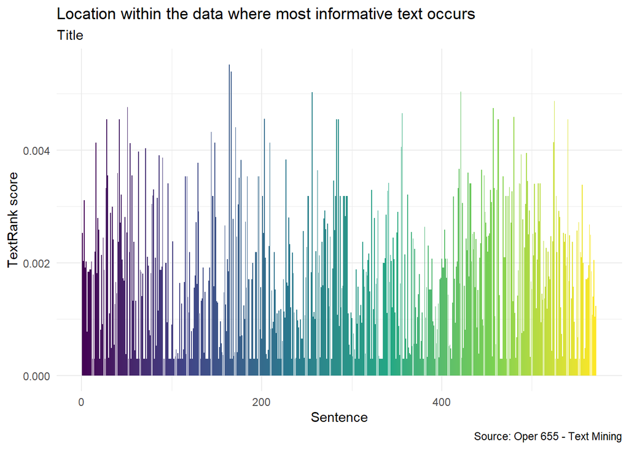

```r
#This shows where, within the document, you see the most important text.

article_summary[["sentences"]] %>%
  ggplot(aes(textrank_id, textrank, fill = textrank_id)) +
  geom_col() +
  theme_minimal() +
  scale_fill_viridis_c() +
  guides(fill = "none") +
  labs(x = "Sentence",
       y = "TextRank score",
       title = "Location within the data where most informative text occurs",
       subtitle = 'Title',
       caption = "Source: Oper 655 - Text Mining")
```

```r
library(udpipe)
library(textrank)
## First step: Take the English udpipe model and annotate the text.
ud_model <- udpipe_download_model(language = "english")
```

```
## Visit https://github.com/jwijffels/udpipe.models.ud.2.4 for model license details
```

```r
ud_model <- udpipe_load_model(ud_model$file_model)
x <- udpipe_annotate(ud_model, x = text)
x <- as.data.frame(x)
head(x)
```

```
##   doc_id paragraph_id sentence_id
## 1   doc1            1           1
## 2   doc1            1           1
## 3   doc1            1           1
## 4   doc1            1           1
## 5   doc2            1           1
## 6   doc2            1           1
##                                                     sentence token_id token
## 1                                                 oh, hello.        1    oh
## 2                                                 oh, hello.        2     ,
## 3                                                 oh, hello.        3 hello
## 4                                                 oh, hello.        4     .
## 5 you're, uh, you're probably here about the, uh, the story.        1   you
## 6 you're, uh, you're probably here about the, uh, the story.        2   're
##   lemma  upos xpos                            feats head_token_id   dep_rel
## 1    oh  INTJ   UH                             <NA>             3 discourse
## 2     , PUNCT    ,                             <NA>             3     punct
## 3 hello  INTJ   UH                             <NA>             0      root
## 4     . PUNCT    .                             <NA>             3     punct
## 5   you  PRON  PRP   Case=Nom|Person=2|PronType=Prs             9     nsubj
## 6    be   AUX  VBP Mood=Ind|Tense=Pres|VerbForm=Fin             9       cop
##   deps            misc
## 1 <NA>   SpaceAfter=No
## 2 <NA>            <NA>
## 3 <NA>   SpaceAfter=No
## 4 <NA> SpacesAfter=\\n
## 5 <NA>   SpaceAfter=No
## 6 <NA>   SpaceAfter=No
```

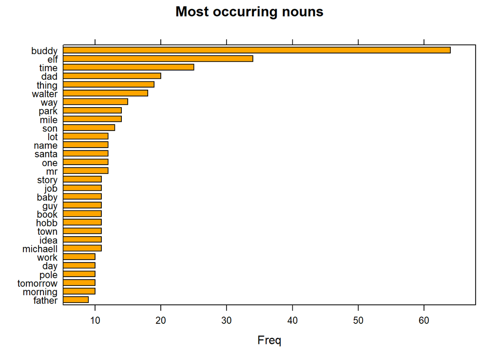

```r
#Lemma is just the column of all of the words in the document
#Here we simply show the frequency of the words.
stats <- subset(x, upos %in% "NOUN")
stats <- txt_freq(x = stats$lemma)
stats$key <- factor(stats$key, levels = rev(stats$key))

barchart(key ~ freq, data = head(stats, 30), col = "orange", main = "Most occurring nouns", xlab = "Freq")
```

```r
stats <- keywords_collocation(x = x,
                              term = "token", group = c("doc_id", "paragraph_id", "sentence_id"),
                              ngram_max = 4)
## Co-occurrences: How frequent do words occur in the same sentence, in this case only nouns or adjectives
stats <- cooccurrence(x = subset(x, upos %in% c("NOUN", "ADJ")),
                      term = "lemma", group = c("doc_id", "paragraph_id", "sentence_id"))
## Co-occurrences: How frequent do words follow one another
stats <- cooccurrence(x = x$lemma,
                      relevant = x$upos %in% c("NOUN", "ADJ"))
## Co-occurrences: How frequent do words follow one another even if we would skip 2 words in between
stats <- cooccurrence(x = x$lemma,
                      relevant = x$upos %in% c("NOUN", "ADJ"), skipgram = 2)
head(stats)
```

```
##     term1   term2 cooc
## 1   north    pole    9
## 2 central    park    8
## 3     new    york    7
## 4  tickle   fight    7
## 5    good morning    6
## 6      ho      ho    6
```

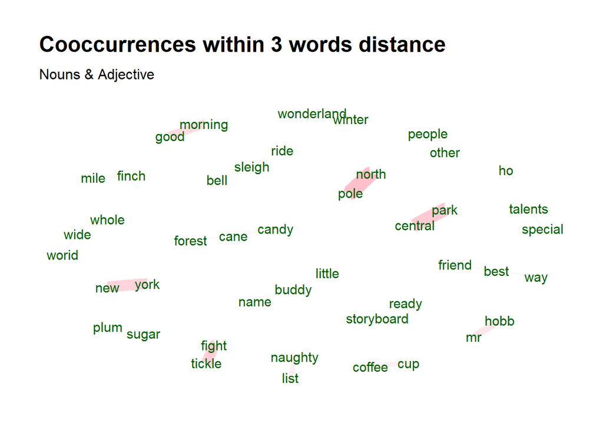

```r
#From here we build out a word network showing how closely related and used together multi word phrases are in the document.
wordnetwork <- head(stats, 30)
wordnetwork <- graph_from_data_frame(wordnetwork)

ggraph(wordnetwork, layout = "fr") +
  geom_edge_link(aes(width = cooc, edge_alpha = cooc), edge_colour = "pink") +
  geom_node_text(aes(label = name), col = "darkgreen", size = 4) +
  theme_graph(base_family = "Arial Narrow") +
  theme(legend.position = "none") +
  labs(title = "Cooccurrences within 3 words distance", subtitle = "Nouns & Adjective")
```

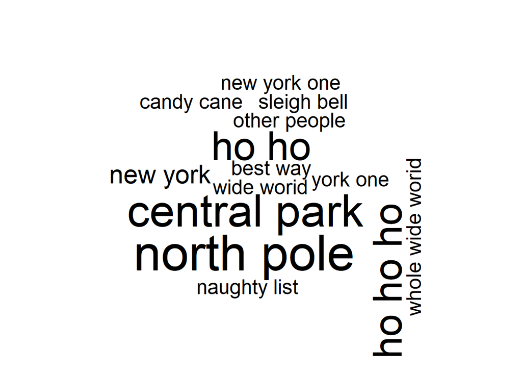

```r
stats <- textrank_keywords(x$lemma,
                           relevant = x$upos %in% c("NOUN", "ADJ"),
                           ngram_max = 8, sep = " ")
stats <- subset(stats$keywords, ngram > 1 & freq >= 3)

wordcloud(words = stats$keyword, freq = stats$freq, max.words = 300)
```

```r
stats <- keywords_rake(x = x,
                       term = "token", group = c("doc_id", "paragraph_id", "sentence_id"),
                       relevant = x$upos %in% c("NOUN", "ADJ"),
                       ngram_max = 4)
head(subset(stats, freq > 3))
```

```
##         keyword ngram freq     rake
## 5      new york     2    5 2.357143
## 7    north pole     2    9 2.100000
## 17 central park     2    6 1.964286
## 18 tickle fight     2    7 1.875000
## 37 good morning     2    6 1.052941
## 44       little     1    8 0.850000
```

```r
## Simple noun phrases (a adjective+noun, pre/postposition, optional determiner and another adjective+noun)
x$phrase_tag <- as_phrasemachine(x$upos, type = "upos")
stats <- keywords_phrases(x = x$phrase_tag, term = x$token,
                          pattern = "(A|N)+N(P+D*(A|N)*N)*",
                          is_regex = TRUE, ngram_max = 4, detailed = FALSE)
head(subset(stats, ngram > 2))
```

```
##               keyword ngram freq
## 25   whole wide worid     3    3
## 34  candy cane forest     3    3
## 52 best cup of coffee     4    2
## 64       me one phone     3    2
## 65  me one phone call     4    2
## 67     one phone call     3    2
```

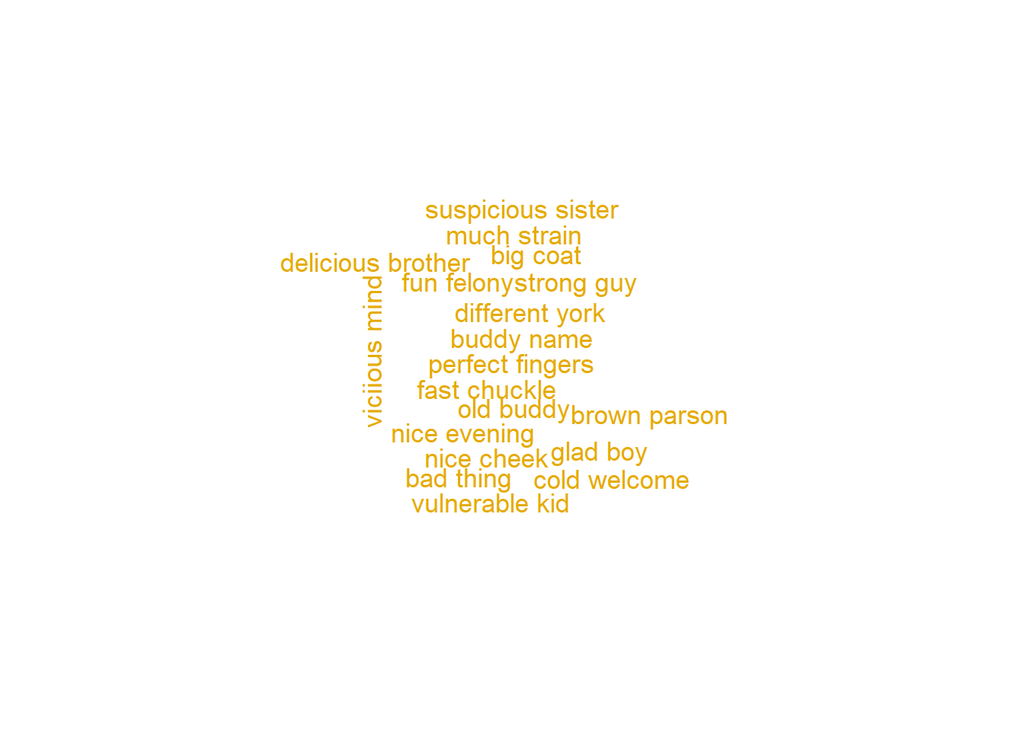

```r
#Lastly, we identify the most common phrases in the dataset to get a feel for the overall docuement.
stats <- merge(x, x,
               by.x = c("doc_id", "paragraph_id", "sentence_id", "head_token_id"),
               by.y = c("doc_id", "paragraph_id", "sentence_id", "token_id"),
               all.x = TRUE, all.y = FALSE,
               suffixes = c("", "_parent"), sort = FALSE)
stats <- subset(stats, dep_rel %in% "nsubj" & upos %in% c("NOUN") & upos_parent %in% c("ADJ"))
stats$term <- paste(stats$lemma_parent, stats$lemma, sep = " ")
stats <- txt_freq(stats$term)

wordcloud(words = stats$key, freq = stats$freq, min.freq = 3, max.words = 100,
          random.order = FALSE, colors = brewer.pal(6, "Dark2"), scale = c(1.1,5))
```